# Bayesian GLMM Part2

```
Note: uncertainty of error terms are not taken into account. Consider
  setting `interval` to "prediction". This will call `posterior_predict()`
  instead of `posterior_epred()`.
```

```
Data points may overlap. Use the `jitter` argument to add some amount of
  random variation to the location of data points and avoid overplotting.
```

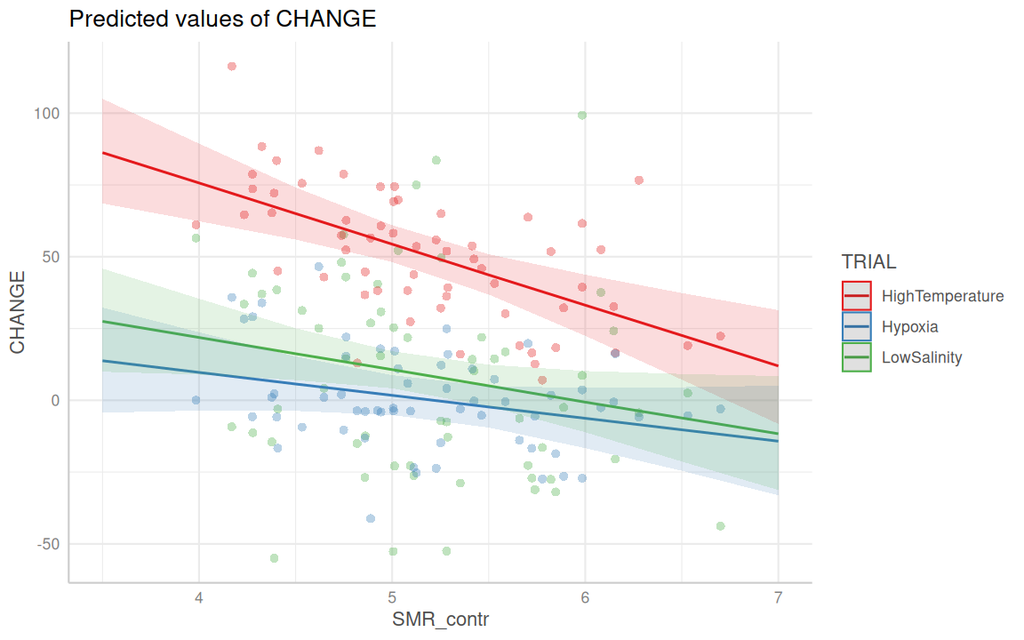

```r
norin_brm3 |>
  ggpredict(~ SMR_contr * TRIAL) |>
  plot(show_data = TRUE)
```

**Plotting prior and posterior**

```r
norin_brm3 |> get_variables()
```

```
 [1] "b_Intercept"                       "b_TRIALHypoxia"
 [3] "b_TRIALLowSalinity"                "b_scaleSMR_contr"
 [5] "b_scaleMASS"                       "b_TRIALHypoxia:scaleSMR_contr"
 [7] "b_TRIALLowSalinity:scaleSMR_contr" "sd_FISHID__Intercept"
 [9] "sigma"                             "Intercept"
[11] "r_FISHID[1,Intercept]"             "r_FISHID[2,Intercept]"
[13] "r_FISHID[3,Intercept]"             "r_FISHID[4,Intercept]"
[15] "r_FISHID[5,Intercept]"             "r_FISHID[6,Intercept]"
[17] "r_FISHID[7,Intercept]"             "r_FISHID[8,Intercept]"
[19] "r_FISHID[9,Intercept]"             "r_FISHID[10,Intercept]"
[21] "r_FISHID[11,Intercept]"            "r_FISHID[12,Intercept]"
[23] "r_FISHID[13,Intercept]"            "r_FISHID[14,Intercept]"
[25] "r_FISHID[15,Intercept]"            "r_FISHID[16,Intercept]"
[27] "r_FISHID[17,Intercept]"            "r_FISHID[18,Intercept]"
[29] "r_FISHID[19,Intercept]"            "r_FISHID[20,Intercept]"
```

[output cut: 26 more lines]

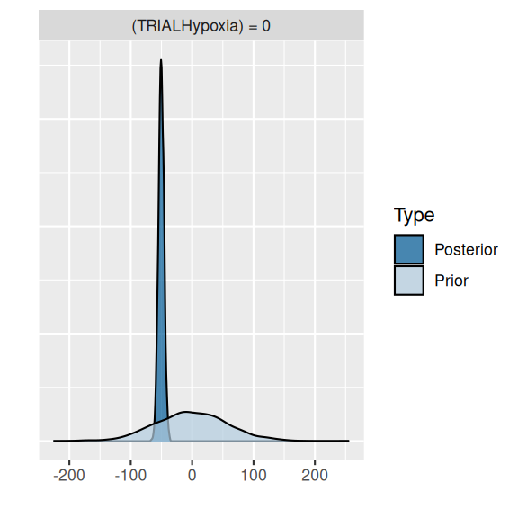

```r
norin_brm3 |>
  hypothesis("TRIALHypoxia=0") |>
  plot()
```

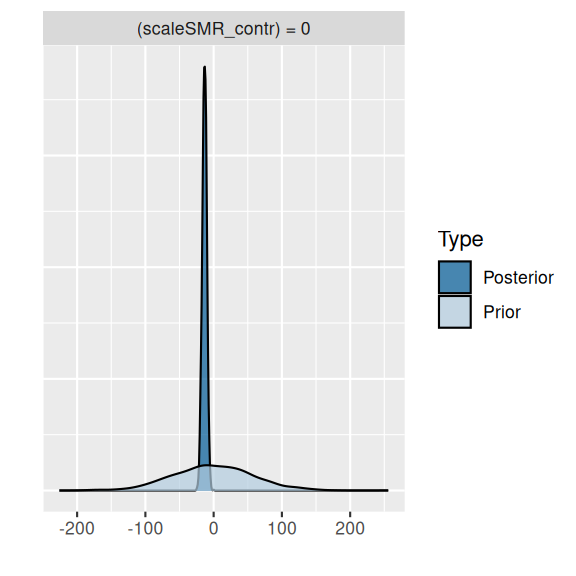

```r
norin_brm3 |>
  hypothesis("scaleSMR_contr=0") |>
  plot()
```

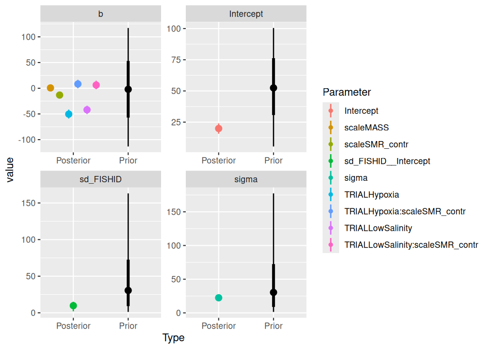

```r
norin_brm3 |> SUYR_prior_and_posterior()
```

**Random intercept/slope model**

While we are here, we might like to explore a random intercept/slope model

```r
priors <- prior(normal(53, 35), class = "Intercept") +
  ## prior(normal(0, 70), class = 'b', coef = 'TRIALHypoxia') +
  ## prior(normal(0, 70), class = 'b', coef = 'TRIALLowSalinity') +
  ## prior(normal(0, 54), class = 'b', coef = 'SMR_contr') +
  ## prior(normal(0, 60), class = 'b', coef = 'MASS') +
  prior(normal(0, 60), class = "b") +
  prior(student_t(3, 0, 40), class = "sigma") +
  prior(student_t(3, 0, 40), class = "sd") +
  prior(lkj_corr_cholesky(1), class = "cor")
norin_form <- bf(CHANGE ~ (TRIAL | FISHID) + TRIAL * scale(SMR_contr) + scale(MASS),
  ## sigma ~ TRIAL*SMR_contr + offset(MASS) + (1|FISHID),
  family = gaussian()
)
norin_brm4 <- brm(norin_form,
  data = norin,
  prior = priors,
  sample_prior = "yes",
  iter = 5000,
  warmup = 1000,
  chains = 3, cores = 3,
  thin = 10,
  refresh = 0,
  control = list(adapt_delta = 0.99),
  backend = "rstan"
)
```

```r
norin_brm4 |> get_variables()
```

```
  [1] "b_Intercept"
  [2] "b_TRIALHypoxia"
  [3] "b_TRIALLowSalinity"
  [4] "b_scaleSMR_contr"
  [5] "b_scaleMASS"
  [6] "b_TRIALHypoxia:scaleSMR_contr"
  [7] "b_TRIALLowSalinity:scaleSMR_contr"
  [8] "sd_FISHID__Intercept"
  [9] "sd_FISHID__TRIALHypoxia"
 [10] "sd_FISHID__TRIALLowSalinity"
 [11] "cor_FISHID__Intercept__TRIALHypoxia"
 [12] "cor_FISHID__Intercept__TRIALLowSalinity"
 [13] "cor_FISHID__TRIALHypoxia__TRIALLowSalinity"
 [14] "sigma"
 [15] "Intercept"
```

[output cut: 193 more lines]

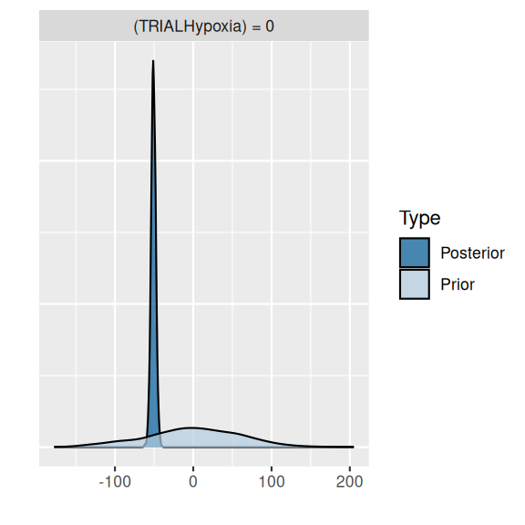

```r
norin_brm4 |>
  hypothesis("TRIALHypoxia=0") |>
  plot()
```

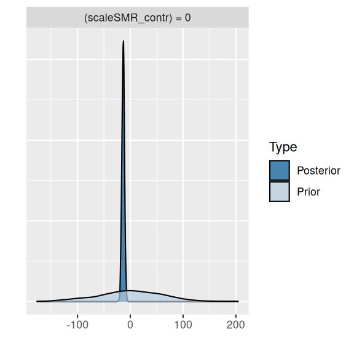

```r
norin_brm4 |>
  hypothesis("scaleSMR_contr=0") |>
  plot()
```

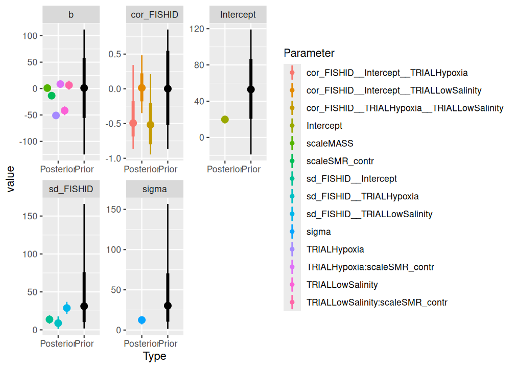

```r
norin_brm4 |> SUYR_prior_and_posterior()
```

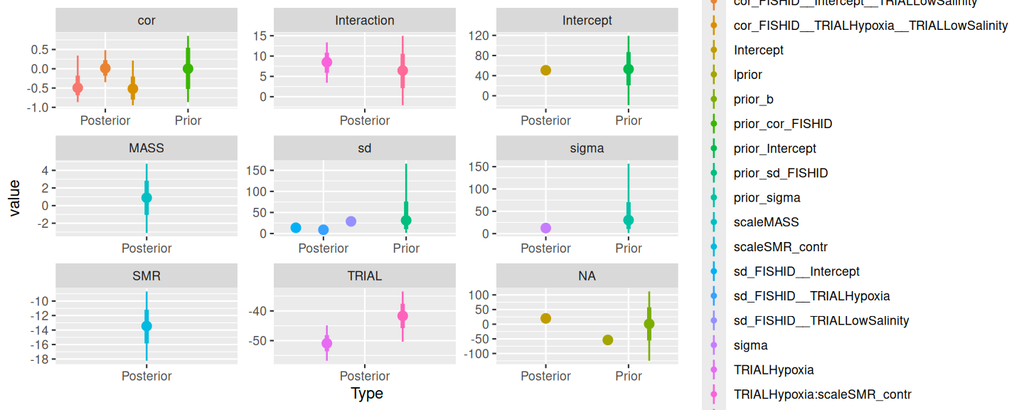

```r
norin_brm4 |>
  posterior_samples() |>
  dplyr::select(-`lp__`) |>
  pivot_longer(everything(), names_to = "key") |>
  filter(!str_detect(key, "^r")) |>
  mutate(
    Type = ifelse(str_detect(key, "prior"), "Prior", "Posterior"),
    Class = case_when(
      str_detect(key, "(^b|^prior).*Intercept$") ~ "Intercept",
      str_detect(key, "b_TRIAL.*|prior_b_TRIAL.*") & !str_detect(key, ".*\\:.*") ~ "TRIAL",
      str_detect(key, "b_scaleSMR_contr|prior_b_SMR_contr") ~ "SMR",
      str_detect(key, "b_scaleMASS|prior_b_MASS") ~ "MASS",
      str_detect(key, ".*\\:.*|prior_b_.*\\:.*") ~ "Interaction",
      str_detect(key, "sd") ~ "sd",
      str_detect(key, "^cor|prior_cor") ~ "cor",
      str_detect(key, "sigma") ~ "sigma"
    ),
    Par = str_replace(key, "b_", "")
  ) |>
  ggplot(aes(x = Type, y = value, color = Par)) +
  stat_pointinterval(position = position_dodge()) +
  facet_wrap(~Class, scales = "free")
```

**Compare models**

We can compare the two models using LOO

```r
(l.1 <- norin_brm3 |> loo())
```

```
Computed from 2400 by 180 log-likelihood matrix.

         Estimate   SE
elpd_loo   -831.6 13.5
p_loo        28.5  4.2
looic      1663.1 27.0
------
MCSE of elpd_loo is NA.
MCSE and ESS estimates assume MCMC draws (r_eff in [0.7, 1.1]).

Pareto k diagnostic values:
                         Count Pct.    Min. ESS
(-Inf, 0.7]   (good)     179   99.4%   149
   (0.7, 1]   (bad)        1    0.6%   <NA>
   (1, Inf)   (very bad)   0    0.0%   <NA>
See help('pareto-k-diagnostic') for details.
```

```r
(l.2 <- norin_brm4 |> loo())
```

```
Computed from 1200 by 180 log-likelihood matrix.

         Estimate   SE
elpd_loo   -767.3  8.5
p_loo        94.2  6.0
looic      1534.6 16.9
------
MCSE of elpd_loo is NA.
MCSE and ESS estimates assume MCMC draws (r_eff in [0.2, 0.5]).

Pareto k diagnostic values:
                          Count Pct.    Min. ESS
(-Inf, 0.68]   (good)     111   61.7%   27
   (0.68, 1]   (bad)       65   36.1%   <NA>
    (1, Inf)   (very bad)   4    2.2%   <NA>
See help('pareto-k-diagnostic') for details.
```

```r
loo_compare(l.1, l.2)
```

```
           elpd_diff se_diff
norin_brm4   0.0       0.0
norin_brm3 -64.3      10.4
```

There is substantially more support for the more complex random intercept/slope model over the simpler random intercept only model. Consequently, we will continue with the random intercept/slope model.

# 6 MCMC sampling diagnostics

**brms**

**bayesplot**

The `bayesplot` package offers a range of MCMC diagnostics as well as Posterior Probability Checks (PPC), all of which have a convenient `plot()` interface. Lets start with the MCMC diagnostics.

**See list of available diagnostics by name**

```r
available_mcmc()
```

```
bayesplot MCMC module:
  mcmc_acf
  mcmc_acf_bar
  mcmc_areas
  mcmc_areas_ridges
  mcmc_combo
  mcmc_dens
  mcmc_dens_chains
  mcmc_dens_overlay
  mcmc_hex
  mcmc_hist
  mcmc_hist_by_chain
  mcmc_intervals
  mcmc_neff
  mcmc_neff_hist
  mcmc_nuts_acceptance
  mcmc_nuts_divergence
  mcmc_nuts_energy
  mcmc_nuts_stepsize
  mcmc_nuts_treedepth
  mcmc_pairs
  mcmc_parcoord
  mcmc_rank_ecdf
  mcmc_rank_hist
  mcmc_rank_overlay
  mcmc_recover_hist
  mcmc_recover_intervals
  mcmc_recover_scatter
  mcmc_rhat
  mcmc_rhat_hist
  mcmc_scatter
  mcmc_trace
  mcmc_trace_highlight
  mcmc_violin
```

Of these, we will focus on:

- trace: this plots the estimates of each parameter over the post-warmup length of each MCMC chain. Each chain is plotted in a different shade of blue, with each parameter in its own facet. Ideally, each **trace** should just look like noise without any discernible drift and each of the traces for a specific parameter should look the same (i.e, should not be displaced above or below any other trace for that parameter).

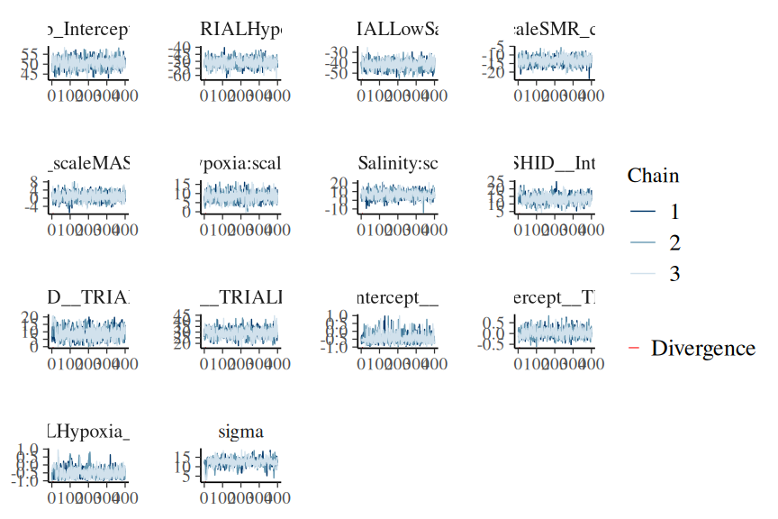

```r
norin_brm4 |> mcmc_plot(type = "trace")
```

The chains appear well mixed and very similar

- acf_bar (autocorrelation function): plots the autocorrelation between successive MCMC sample lags for each parameter and each chain

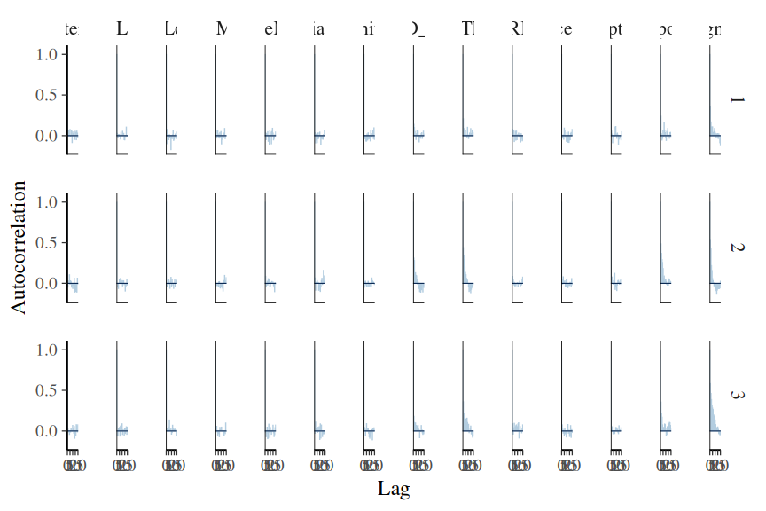

```r
norin_brm4 |> mcmc_plot(type = "acf_bar")
```

- rhat_hist: Rhat is a **scale reduction factor** measure of convergence between the chains. The closer the values are to 1, the more the chains have converged. Values greater than 1.05 indicate a lack of convergence. There will be an Rhat value for each parameter estimated.

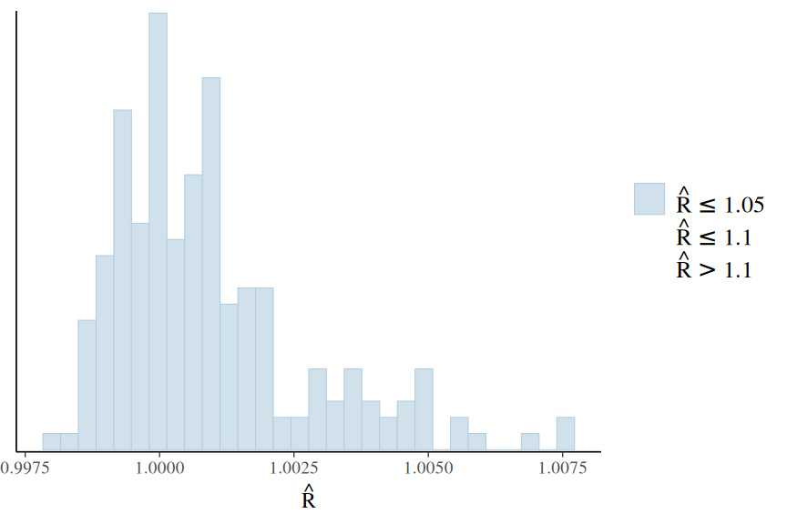

```r
norin_brm4 |> mcmc_plot(type = "rhat_hist")
```

All Rhat values are below 1.05, suggesting the chains have converged.

- neff_hist (number of effective samples): the ratio of the number of effective samples (those not rejected by the sampler) to the number of samples provides an indication of the effectiveness (and efficiency) of the MCMC sampler. Ratios that are less than 0.5 for a parameter suggest that the sampler spent considerable time in difficult areas of the sampling domain and rejected more than half of the samples (replacing them with the previous effective sample).

  If the ratios are low, tightening the priors may help.

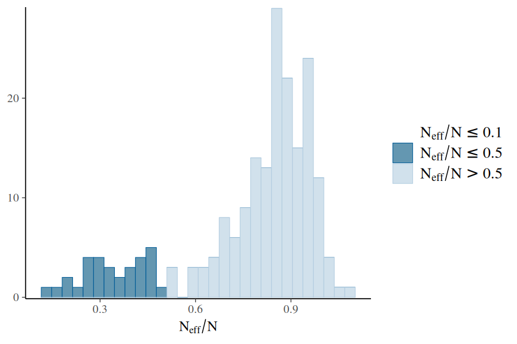

```r
norin_brm4 |> mcmc_plot(type = "neff_hist")
```

There are a small number of parameters that have very low effective sample sizes. It might be worth exploring the cause(s) of this to determine whether it is concerning.

**More diagnostics**

[figure not shown]

```r
norin_brm4 |> mcmc_plot(type = "combo")
```

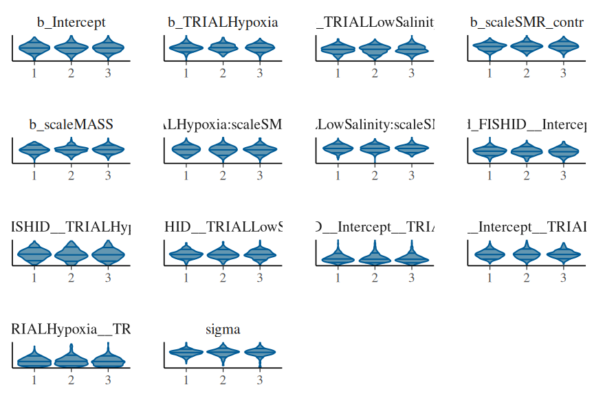

```r
norin_brm4 |> mcmc_plot(type = "violin")
```

**stan plots**

The `rstan` package offers a range of MCMC diagnostics. Lets start with the MCMC diagnostics.

Of these, we will focus on:

- stan_trace: this plots the estimates of each parameter over the post-warmup length of each MCMC chain. Each chain is plotted in a different colour, with each parameter in its own facet. Ideally, each **trace** should just look like noise without any discernible drift and each of the traces for a specific parameter should look the same (i.e, should not be displaced above or below any other trace for that parameter).

```r
norin_brm4 |> get_variables()
```

```
  [1] "b_Intercept"
  [2] "b_TRIALHypoxia"
  [3] "b_TRIALLowSalinity"
  [4] "b_scaleSMR_contr"
  [5] "b_scaleMASS"
  [6] "b_TRIALHypoxia:scaleSMR_contr"
  [7] "b_TRIALLowSalinity:scaleSMR_contr"
  [8] "sd_FISHID__Intercept"
  [9] "sd_FISHID__TRIALHypoxia"
 [10] "sd_FISHID__TRIALLowSalinity"
 [11] "cor_FISHID__Intercept__TRIALHypoxia"
 [12] "cor_FISHID__Intercept__TRIALLowSalinity"
 [13] "cor_FISHID__TRIALHypoxia__TRIALLowSalinity"
 [14] "sigma"
 [15] "Intercept"
```

[output cut: 193 more lines]

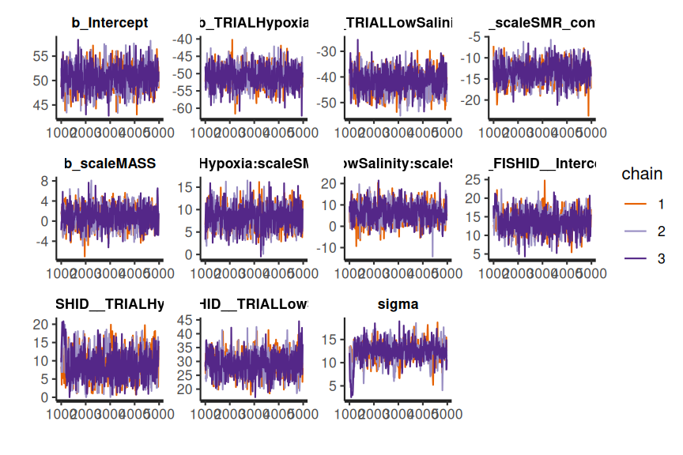

```r
pars <- norin_brm4 |> get_variables()
pars <- str_extract(pars, "^b_.*|^sigma$|^sd.*") |> na.omit()

norin_brm4$fit |>
  stan_trace(pars = pars)
```

The chains appear well mixed and very similar

- stan_acf (autocorrelation function): plots the autocorrelation between successive MCMC sample lags for each parameter and each chain

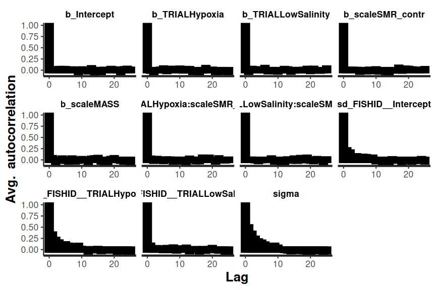

```r
norin_brm4$fit |>
  stan_ac(pars = pars)
```

- stan_rhat: Rhat is a **scale reduction factor** measure of convergence between the chains. The closer the values are to 1, the more the chains have converged. Values greater than 1.05 indicate a lack of convergence. There will be an Rhat value for each parameter estimated.

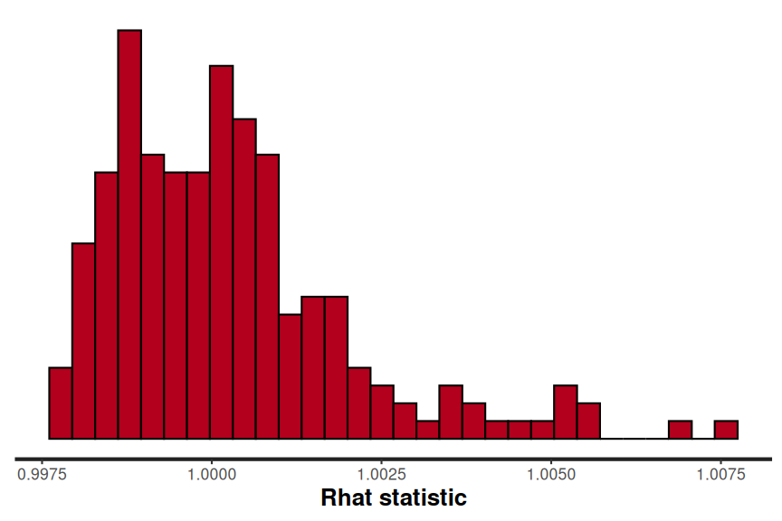

```r
norin_brm4$fit |> stan_rhat()
```

All Rhat values are below 1.05, suggesting the chains have converged.

- stan_ess (number of effective samples): the ratio of the number of effective samples (those not rejected by the sampler) to the number of samples provides an indication of the effectiveness (and efficiency) of the MCMC sampler. Ratios that are less than 0.5 for a parameter suggest that the sampler spent considerable time in difficult areas of the sampling domain and rejected more than half of the samples (replacing them with the previous effective sample).

  If the ratios are low, tightening the priors may help.

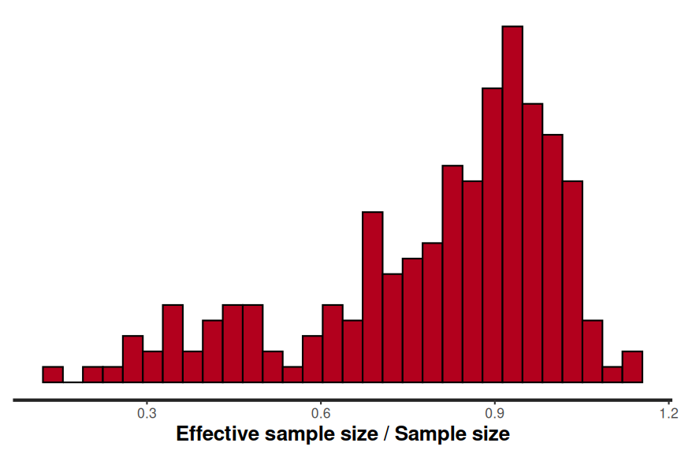

```r
norin_brm4$fit |> stan_ess()
```

There are a small number of parameters that have very low effective sample sizes. It might be worth exploring the cause(s) of this to determine whether it is concerning.

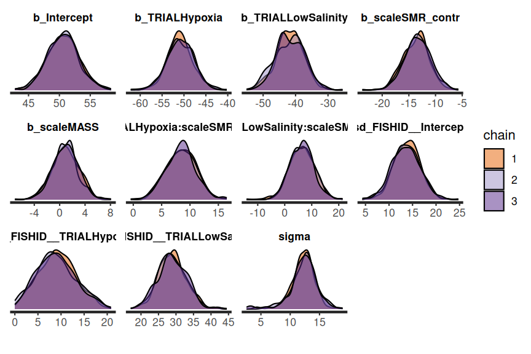

```r
norin_brm4$fit |>
  stan_dens(separate_chains = TRUE, pars = pars)
```

**ggmcmc**

The `ggmean` package also as a set of MCMC diagnostic functions. Lets start with the MCMC diagnostics.

Of these, we will focus on:

- ggs_traceplot: this plots the estimates of each parameter over the post-warmup length of each MCMC chain. Each chain is plotted in a different colour, with each parameter in its own facet. Ideally, each **trace** should just look like noise without any discernible drift and each of the traces for a specific parameter should look the same (i.e, should not be displaced above or below any other trace for that parameter).

[figure not shown]

```r
norin_ggs <- norin_brm4 |> ggs(burnin = FALSE, inc_warmup = FALSE)
norin_ggs |> ggs_traceplot()
```

The chains appear well mixed and very similar

- gss_autocorrelation (autocorrelation function): plots the autocorrelation between successive MCMC sample lags for each parameter and each chain

[figure not shown]

```r
ggs_autocorrelation(norin_ggs)
```

There is no evidence of autocorrelation in the MCMC samples

- stan_rhat: Rhat is a **scale reduction factor** measure of convergence between the chains. The closer the values are to 1, the more the chains have converged. Values greater than 1.05 indicate a lack of convergence. There will be an Rhat value for each parameter estimated.

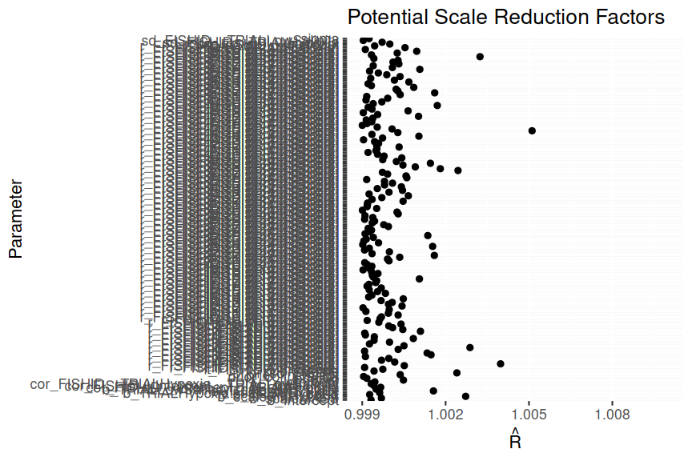

```r
ggs_Rhat(norin_ggs, scaling = 1.01)
```

All Rhat values are below 1.01, suggesting the chains have converged.

- stan_ess (number of effective samples): the ratio of the number of effective samples (those not rejected by the sampler) to the number of samples provides an indication of the effectiveness (and efficiency) of the MCMC sampler. Ratios that are less than 0.5 for a parameter suggest that the sampler spent considerable time in difficult areas of the sampling domain and rejected more than half of the samples (replacing them with the previous effective sample).